# Lab 4 – Sampling Distributions

## Sampling distributions

A sample statistic is simply a function of a random sample. Some examples include the sample mean (sum the sample values and divide by the sample size) and sample median (order the samples and find the middle value). The distribution of a statistic is called a sampling distribution. For example, compare the two statements:

1. “What’s the chance that the lifetime of a lightbulb is greater than 750 hours?”
2. “What’s the chance that the average lifetime of 100 lightbulbs is greater than 750 hours?”

These two statements are similar (‘the chance *some number* is greater than 750’), but the top concerns a single observation while the bottom concerns 100 samples. To answer the bottom question, we will need to know the distribution of the sample mean.

The key is to realize that both questions deal with the same population (both the single lightbulb and 100 lightbulbs are drawn from the same distribution), and, as it turns out, by studying the sampling distribution we can make inferences about the population as a whole.

### Lab Report Template

Your reproducible lab report: Before you get started, download the R Markdown template for this lab. Remember all of your code and answers go in this document:

```r
download.file("https://jacobfhsmith.github.io/STA101LFall2020/sta101_lab4.Rmd", destfile="sta101_lab4.Rmd")
```

##### The Central Limit Theorem (CLT)

Question one can often be very challenging to directly answer while question two can be very easy (provided we sample enough lightbulbs). This is due to the *Central Limit Theorem (CLT)*. The CLT basically states that the distribution of the sample mean will be approximately normal for a large enough sample size. In the context above, this means that the distribution of the sample average of 100 (or 100,000) lightbulbs will look normally distributed, even though the distribution of a *single* lightbulb might be highly skewed and non-normal.

##### Standard error

The *standard error* is simply the standard deviation of the sampling distribution.

For example, if we kept taking 100 lightbulbs off of the factory line and computing the average lifetime, we would expect the average lifetime itself to vary between samples of size 100. This variability is due to the randomness of the individual lightbulbs, so the variability of the sample mean and the individual lightbulbs is related, but not exactly the same. To avoid confusion, we will call the standard deviation of the average lifetime the *standard error* and the standard deviation of the individual lightbulbs…well…the standard deviation.

## Setting random seed

In this lab, we will be simulating random numbers. In order to make your work reproducible, you will need to set a ‘seed’ at the beginning of your code. In doing so, each time you knit your document the same random numbers are generated. Note that if you set a seed in your R console and begin simulating random numbers, different numbers will appear each time; only by knitting the document will you see the same random numbers produced.

## Packages used

##### Dplyr

*Dplyr* is a powerful package when it comes to data manipulation. Common functions are select, mutate, transmute, filter, group_by, arrange, count, summarise, slice, sample_n, etc. Use ? followed by function names in the R console to look at the documentation i.e. ?select, or refer to the data wrangling cheatsheet: https://rstudio.com/wp-content/uploads/2015/02/data-wrangling-cheatsheet.pdf

##### Pipeline operator %>%

This is an operator in the *dplyr* package that can make your coding easier and more readable, especially when you have many functions in your pipeline. Its name is simply an adaption of pipeline in manufacturers. For example, a car factory assembles cars in four steps: mounting wheels on base of vehicles, putting interior in place, installing the body of vehicles and painting. (I totally made this up, it should be a lot more complicated than this.)

##### Dpylr and %>% Operator Examples

Here we load package *tidyverse*. It is the parental package of common packages such as *dplyr*, *ggplot2*, *tidyr*, *purrr*, etc.

```r
library(tidyverse)
```

Let’s say we want to select a continuous variable from a dataset, group by a categorical variable, and obtain the largest three values within each category. What would you do?

```r
mpg %>% select(cty, manufacturer, class) %>%
  group_by(manufacturer, class) %>%
  arrange(desc(cty), .by_group = T) %>%
  slice(1:3) %>%
  head(9)
```

```
## # A tibble: 9 x 3
## # Groups:   manufacturer, class [3]
##     cty manufacturer class
##   <int> <chr>        <chr>
## 1    21 audi         compact
## 2    21 audi         compact
## 3    20 audi         compact
## 4    17 audi         midsize
## 5    16 audi         midsize
## 6    15 audi         midsize
## 7    16 chevrolet    2seater
## 8    16 chevrolet    2seater
## 9    15 chevrolet    2seater
```

What would this be without *%>%*?

```r
head(slice(arrange(group_by(select(mpg, cty, manufacturer, class), manufacturer, class), desc(cty), .by_group = T), 1:3), 9)
```

```
## # A tibble: 9 x 3
## # Groups:   manufacturer, class [3]
##     cty manufacturer class
##   <int> <chr>        <chr>
## 1    21 audi         compact
## 2    21 audi         compact
## 3    20 audi         compact
## 4    17 audi         midsize
## 5    16 audi         midsize
## 6    15 audi         midsize
## 7    16 chevrolet    2seater
## 8    16 chevrolet    2seater
## 9    15 chevrolet    2seater
```

Which coding style do you prefer?

##### Infer

We will use the *rep_sample_n* function in the *infer* package to repeatedly draw samples with certain sample size from a dataset.

```r
library(infer)
```

## Example

Load the 2012 election data and use the *head()* function to become familiar with the dataset.

```r
election = read.csv("~/election_c.csv")
```

Let’s see the CLT in action. First, we use the dplyr function *filter()* to create a new dataframe corresponding to election results for the state of Georgia. Think of each area of Georgia as an observation from a population (there’s 159 areas of Georgia in this dataset).

We look at the number of Democratic votes here, but feel free to change this to Republican, Third party, and Other votes to get a feel for the CLT.

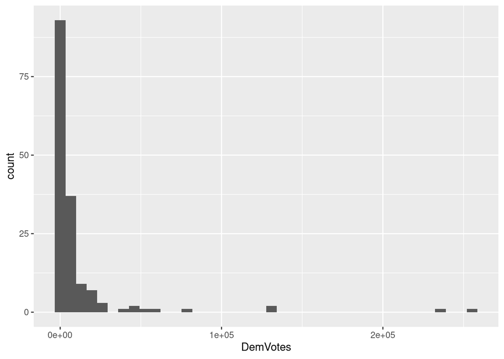

```r
# Set Seed
set.seed(42)

# Filter to areas of Georgia
election_Georgia = election %>% filter(State == 'Georgia')
# Plot histogram to view distribution of Democratic votes
election_Georgia %>% ggplot(aes(x=DemVotes)) + geom_histogram(bins=40)
```

Do you think *DemVotes* is normally distributed? The ‘helper’ function coded below takes the arguments *dataset*, *size*, *variable* and outputs a dataframe of 5000 simulated sample means. Try looking at the *head()* of the *sample_size_10* dataframe to get a feel for the *sample_variable()* function.

Take a look at the density plot below. What happens as the sample size, $n$, increases?

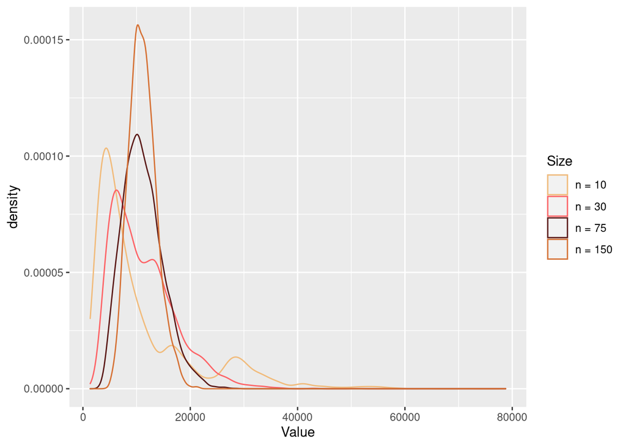

```r
# Function to simulate sample means for given dataset,size,variable
sample_variable = function(dataset,size,variable) {
  rep_sample_n(dataset, size = size, replace = T, reps = 5000) %>%
  summarise(sample_mean = mean(!!sym(variable)),.groups = 'drop') %>%
  .[,2]
}

# Simulates sample means for various sample sizes
sample_size_10 = sample_variable(election_Georgia,10,"DemVotes")
sample_size_30 = sample_variable(election_Georgia,30,"DemVotes")
sample_size_75 = sample_variable(election_Georgia,75,"DemVotes")
sample_size_150 = sample_variable(election_Georgia,150,"DemVotes")


# Creates a density plot for each sample size
data.frame(sample_size_10,sample_size_30,sample_size_75,sample_size_150) %>%
  gather("Size","Value") %>%
  ggplot(aes(x=Value,col=Size)) + geom_density() +
  scale_color_manual(labels = c('n = 10','n = 30','n = 75','n = 150'),
                       values=c("#F1BB7B", "#FD6467", "#5B1A18", "#D67236"))
```

## Exercises

### 1 (10%)

With the CLT in mind, hopefully it is clear that the Normal distribution is (extremely) important. In this exercise, you will become familiar with various “normal distribution functions” in R:

- dnorm: evaluates the density of the normal distribution — the value of the normal curve at some point.
- pnorm: gives you the probability under a normal distribution — probability of a value falling greater/less than a chosen point.
- qnorm: inverse of pnorm — gives you the point for which the probability of falling greater/less than is some value.
- rnorm: gives you random variables from a normal distribution.

Refer to https://www.statology.org/dnorm-pnorm-rnorm-qnorm-in-r/ for more information.

Let’s assume that the true standard deviation of the number of Democratic votes for areas of Georgia is $\sigma_{X} \approx 32192.55$. Suppose we sample $n = 150$ areas of Georgia, in which case the standard error is $\sigma_{\bar{X}} \approx \frac{32192.55}{\sqrt{150}} = 2628.511$. For now, we will assume that the mean of the sampling distribution is $\mu_{\bar{X}} \approx 11127$. Therefore, the sampling distribution of the sample mean is a $N(11127,2628.511)$ random variable

1. What is the probability that the (sample) average number of votes is greater than 13,000? (3%)
2. What is the 68th percentile of our sampling distribution (3%)
3. Generate 500 random samples from our sampling distribution. Make a density plot and compare to the $n=150$ plot in the previous section. Do they look alike? Make sure you include the *xlim(0,80000)* argument to put the histogram on the same scale (4%)

```r
# include the following code after geom_density: + xlim(0,80000)
```

### 2 (10%)

The Binomial distribution is an important discrete dstribution. It has two parameters: the number of trials and the probability of a success. Similarly, dbinom, pbinom, qbinom, rbinom are the functions for binomial distribution, with the same purposes as the normal distribution functions above.

Refer to https://www.statology.org/dbinom-pbinom-qbinom-rbinom-in-r/ for more information.

There were 51 states in the dataset (D.C. was treated as a state). 24 of these states voted majority Republican in the 2012 election. Let’s model future elections by assuming that the 2012 election is representative of all elections to follow. So, under our model, the number of majority Republican states is a $\text{Binomal}\left(p = \frac{24}{51}, n=51\right)$ random variable.

1. What is the probability that over half of the states will vote majority Republican in the next election (treating D.C. as the $51^{\text{st}}$ state)? (3%)
2. What is the $30^{\text{th}}$ percentile under our model? (3%)
3. Generate 500 random samples from our model and make a histogram. Set the bin size to 100 (use *?geom_histogram()* to see where the *bins=* argument goes). (4%)

### 3 (15%)

Create a new dataset containing only election results for Texas. Order the dataframe by *TotalVotes*. Which area of Texas has the largest total votes?

### 4 (15%)

Obtain the ratio of Democratic votes to Republican votes for each area of Texas. Create a new dataframe consisting of only three columns: the computed ratio, *Area*, and *CensusPop*.

### 5 (10%)

Create a barplot of the ratios for each area. Make the shade of each bar correspond to the population of the area (*hint: use the ‘alpha’ argument in the aes() function* ). Uncomment the code below and replace the “?” with the correct code

Values greater than the red line indicate more Democratic votes than Republican votes. Where do the top five most populous areas fall relative to this line? Order the dataframe from the previous exercise by *CensusPop* to check your answer.

```r
# Uncomment the code below and fill in the correct arguments
# All you need to do is fill out the "?" with the correct command

# ggplot(?) + ? + geom_hline(yintercept=1,col='red',linetype='dashed',size=0.1)
```

### 6 (20%)

Obtain the sampling distribution of the sample mean ratio for sample sizes 10 and 30. You might have heard the rule of thumb: “the sample mean is approximately normal, provided $n \geq 30$.” Is that necessarily true here?

### 7 (20%)

Redo the problem above for samples sizes 100 and 200 (there are only 254 areas in Texas). Describe the change in the sampling distribution. (15%)

Based on the simulation above for a sample size of 200, suppose we conclude that the mean of the sampling distribution is approximately $0.54$. Give an interpretation of this value. (5%)

## Data Reference

Data for this lab was sourced from the CQ Press Voting and Elections Collection: https://library.cqpress.com/elections/